# savingSessions: energy analysis

Author

Ben Anderson (@dataknut)

Published

January 25, 2023

# 1 No longer updated

See the integrated electricity demand and twitter report instead.

# 2 Introduction

UK ‘demand flexibility service’ [DFS](https://www.nationalgrideso.com/industry-information/balancing-services/demand-flexibility) experiments/trials/‘live’ events by NG-ESO and retailers such as [@OctopusEnergy](https://twitter.com/SavingSessions)

- DFS began on 1 November 2022.
- The service will run until March 2023.

Relevant media articles:

- Monday 23rd Jan 2023: https://www.bbc.co.uk/news/business-64367504
- Tuesday 24th Jan 2023: https://www.bbc.co.uk/news/business-64372264

> Q: Is there a noticeable ‘dip’ in demand?

(Can we even tell?)

# 3 Code setup

Part of https://github.com/dataknut/savingSessions

# 4 Getting data

Use the half-hourly NG-ESO ‘generation mix’ [data](https://data.nationalgrideso.com/carbon-intensity1/historic-generation-mix) as a reasonable proxy for ‘demand’.

> Should probably use the [demand data](https://data.nationalgrideso.com/demand/historic-demand-data) instead as it includes embedded wind & solar.

Variables of interest:

- GENERATION is in MW. It has some exclusions, its just an indicator.
- CARBON_INTENSITY is in g CO2/kWh - we’d expect this to be high during *DFS* events (as we’re trying to avoid the use of high carbon & expensive generation?)

# 5 Analysis

Simple comparison of the ‘demand response session’ day half-hourly demand with the mean half-hourly demand for the previous n days.

All sorts of caveats apply:

- not all of these sessions were national ‘live’ events, some were trials by a single retailer (Octopus)
- we may not be comparing like with like (cold vs warm, weekday vs weekend etc)
- we can’t tell from this analysis what demand would have looked like *without* the demand response intervention. That would require all the retailers to aggregate the ‘savings’ they estimate… or a randomised control trial

## 5.1 Session 1 (Octopus: Tue 15 Nov 2022 17:00)

- 2022-11-15 17:00:00 to
- 2022-11-15 18:00:00

(Not all retailers may have taken part in this one)

According to https://energycentral.com/news/octopus-energy-provide-108mw-grid-flexibility-first-%E2%80%98saving-session%E2%80%99:

> “Over 200,000 households reduced their energy demand by 108MW collectively, the same as a gas power station can generate in an hour. If replicated by all UK energy suppliers, this would be over 1GW.”

But https://www.current-news.co.uk/news/octopus-energy-customers-provide-108mw-of-flexibility-during-first-saving-session quotes Octopus as actually saying:

> “if the program was scaled to *all electric smart meter customers* with all supplier[s] in Great Britain, it could create over 1GW of flexible energy load”

The following plot compares the energy use during the *DFS* event with mean energy use over the last 10 days.

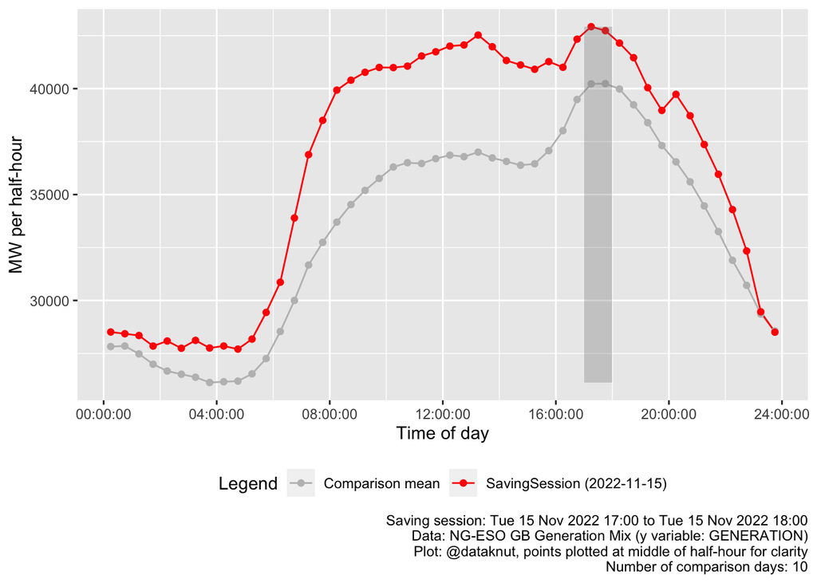

MW comparisons

| hms | Comparison mean | Saving session | MW_diff | pc_diff |
| --- | --- | --- | --- | --- |
| 17:00:00 | 40,226.7 | 42,925.0 | 2,698.3 | 6.7 |
| 17:30:00 | 40,238.7 | 42,736.0 | 2,497.3 | 6.2 |

> Confounding factors:
- recent temperature trends
- recent holidays
- etc

> Note that the comparison plot/table shows the difference between the *DFS* event day and the previous similar days. This does not show what the event day energy use would have been in the absence of the intervention - we’d need a randomised control on the day for that (or a sophisticated demand model as the counterfactual).

Octopus customers’ 108 MW was 0.252 % of mean GB generation (42.925 GW) over the hour of the session (see NG-ESO data above).

108 MW over 200,000 customers is 5.4^{-4} MW per household or, more sensibly, 0.54 kW per household. A pretty reasonable reduction.

But if 200,000 produced a 108 MW power reduction (0.54 kW per household ), the 1 GW estimate implies we only have 1,851,852 GB households with a smart meter. Really? Or did they mean all suppliers taking part in the scheme?

So:

- If all [~28 million households](https://www.ons.gov.uk/peoplepopulationandcommunity/birthsdeathsandmarriages/families/bulletins/familiesandhouseholds/2021) in the UK did this it would be 1.512^{7} kW. That’s 15.12 GW…
- If we reduce ambition a bit and assume that only the 14 million domestic GB customers with a smart meter as of Q2 2022 did this then that would provide 7.56 GW. Which would be 17.61 % of generation. Not bad aye?

The trouble is… these are octopus customers self-selecting into a trial. You just have to [read the tweets](https://twitter.com/SavingSessions) to see that there are households with installed batteries, pausable heat pumps in well-insulated homes and EV V2G. At what point will we all be similarly equipped?

And just to keep in mind the carbon context:

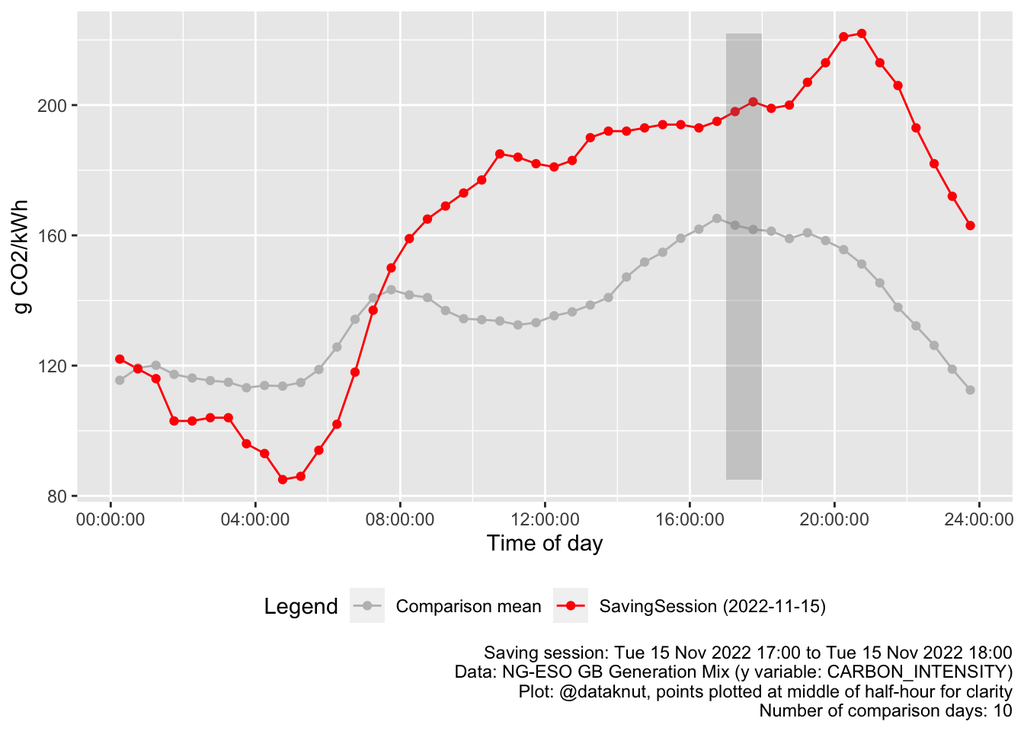

Figure 1: Comparison of carbon intensity

## 5.2 Session 2 (Octopus: Tue 22 Nov 2022 17:30)

- 2022-11-22 17:30:00 to
- 2022-11-22 18:30:00

(Not all retailers may have taken part in this one)

The same caveats about the comparisons apply here…

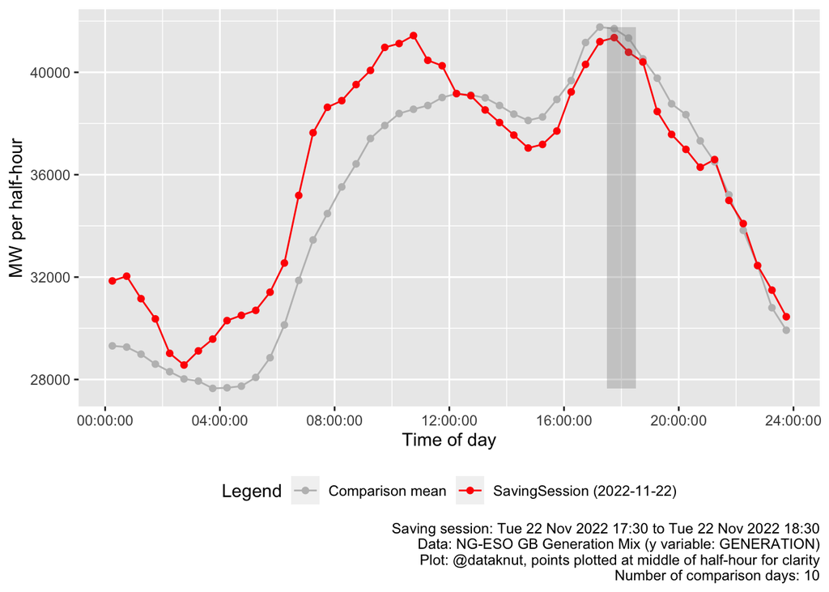

MW comparisons

| hms | Comparison mean | Saving session | MW_diff | pc_diff |
| --- | --- | --- | --- | --- |
| 17:30:00 | 41,706.9 | 41,355.0 | -351.9 | -0.8 |
| 18:00:00 | 41,339.7 | 40,784.0 | -555.7 | -1.3 |

And just to keep in mind the carbon context:

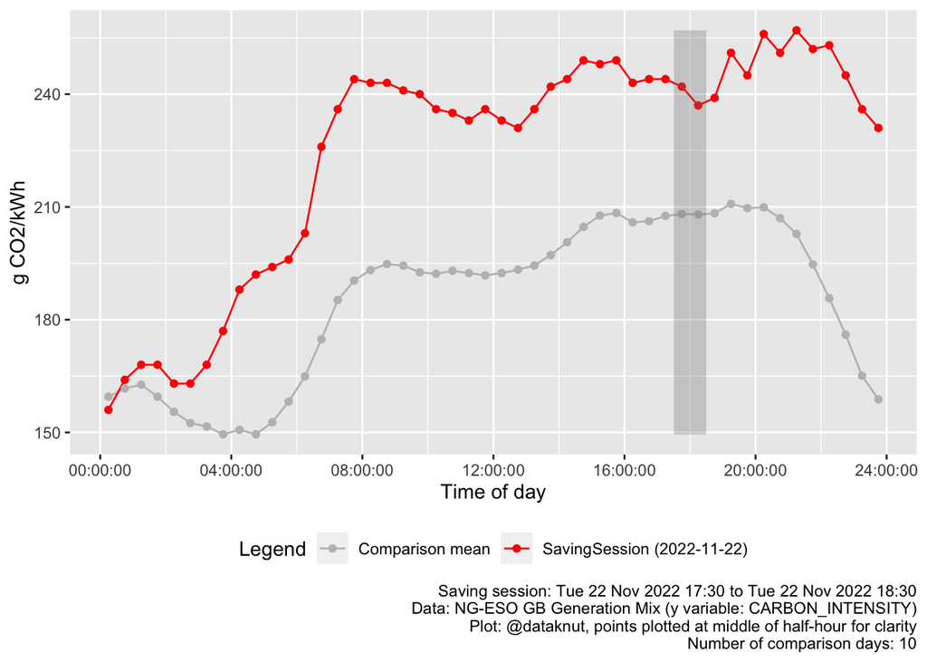

Figure 2: Comparison of carbon intensity

## 5.3 Session 3 (Octopus: Wed 30 Nov 2022 17:30)

(Not all retailers may have taken part in this one)

The same caveats about the comparisons apply here…

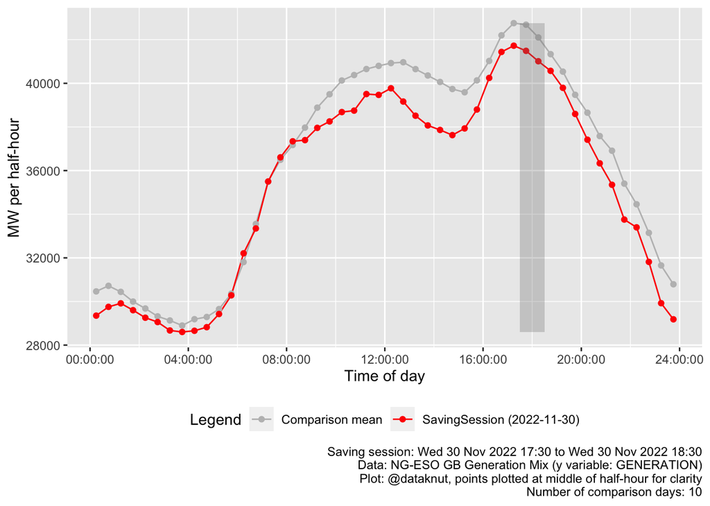

MW comparisons

| hms | Comparison mean | Saving session | MW_diff | pc_diff |
| --- | --- | --- | --- | --- |
| 17:30:00 | 42,687.9 | 41,488.0 | -1,199.9 | -2.8 |
| 18:00:00 | 42,102.9 | 41,011.0 | -1,091.9 | -2.6 |

And just to keep in mind the carbon context:

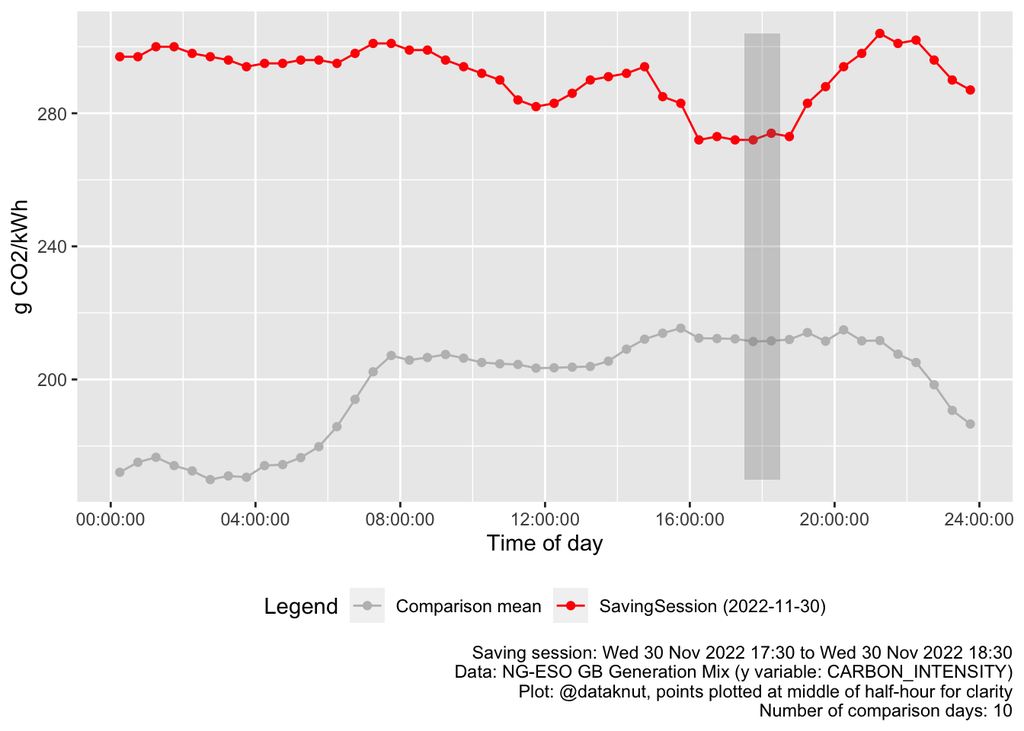

Figure 3: Comparison of carbon intensity

## 5.4 Session 4 (Octopus: Thu 01 Dec 2022 17:00)

- 2022-12-01 17:00:00 to
- 2022-12-01 18:00:00

(Not all retailers may have taken part in this one)

The same caveats about the comparisons apply here…

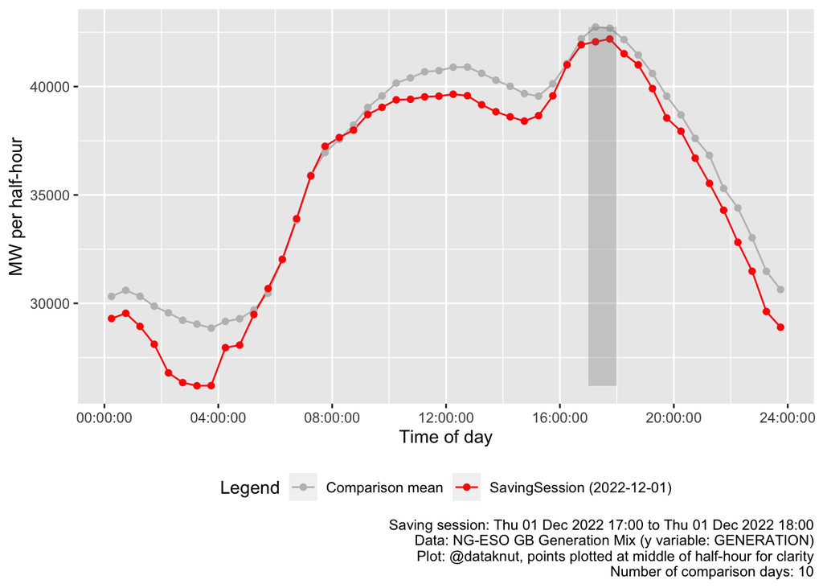

MW comparisons

| hms | Comparison mean | Saving session | MW_diff | pc_diff |
| --- | --- | --- | --- | --- |
| 17:00:00 | 42,751.9 | 42,065.0 | -686.9 | -1.6 |
| 17:30:00 | 42,693.6 | 42,194.0 | -499.6 | -1.2 |

And just to keep in mind the carbon context:

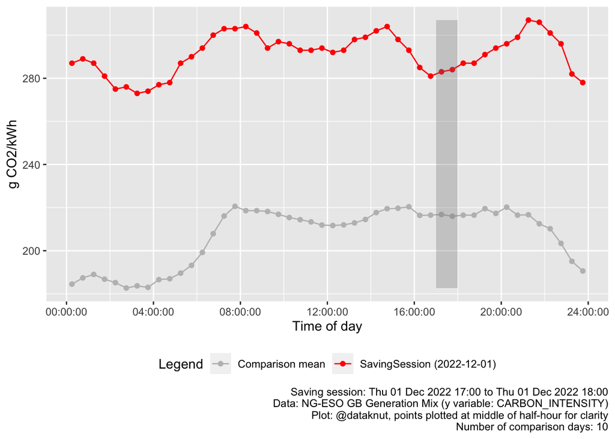

Figure 4: Comparison of carbon intensity

## 5.5 Session 5 (Octopus: Mon 12 Dec 2022 17:00)

- 2022-12-12 17:00:00 to
- 2022-12-12 18:00:00

(Not all retailers may have taken part in this one)

The same caveats about the comparisons apply here…

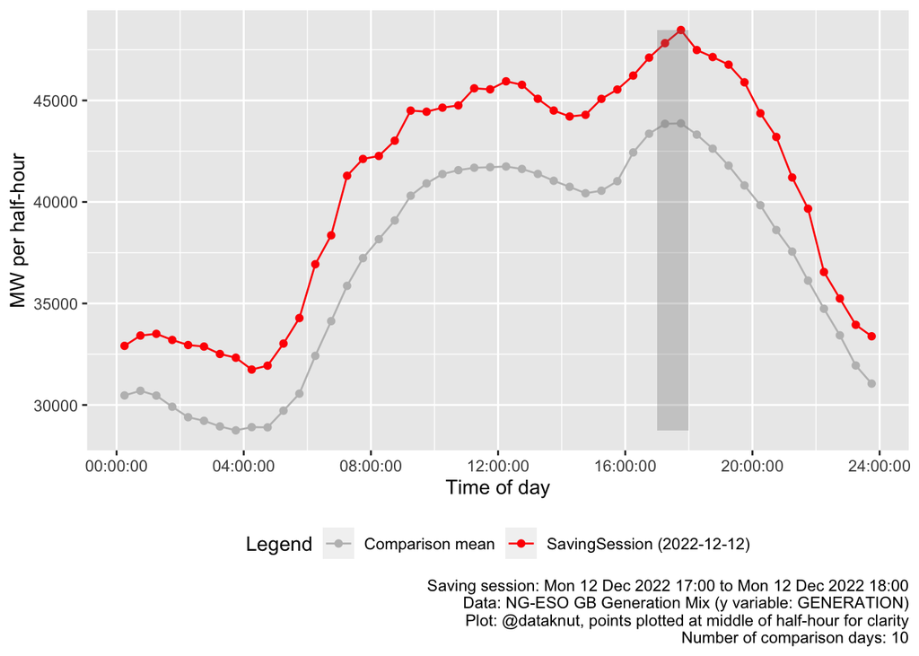

MW comparisons

| hms | Comparison mean | Saving session | MW_diff | pc_diff |
| --- | --- | --- | --- | --- |
| 17:00:00 | 43,849.1 | 47,821.0 | 3,971.9 | 9.1 |
| 17:30:00 | 43,871.3 | 48,470.0 | 4,598.7 | 10.5 |

And just to keep in mind the carbon context:

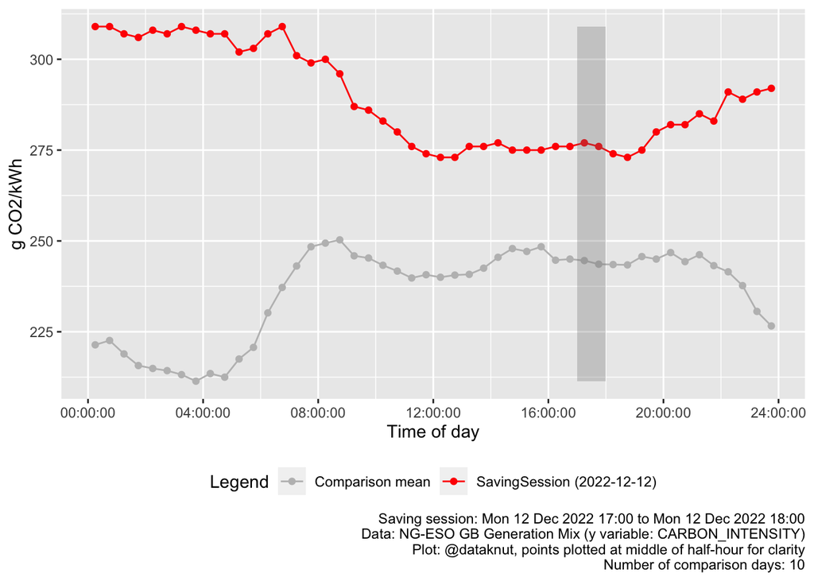

Figure 5: Comparison of carbon intensity

## 5.6 Session 6 (Octopus: Thu 19 Jan 2023 09:00)

- 2023-01-19 09:00:00 to
- 2023-01-19 10:00:00

(Not all retailers may have taken part in this one)

The same caveats about the comparisons apply here…

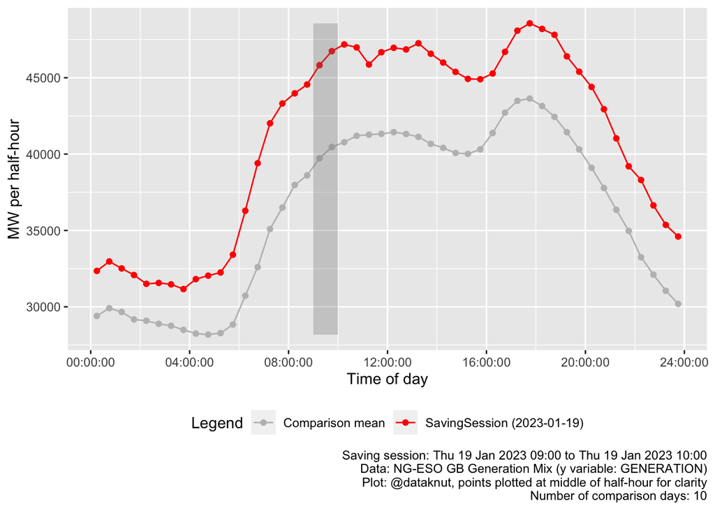

MW comparisons

| hms | Comparison mean | Saving session | MW_diff | pc_diff |
| --- | --- | --- | --- | --- |
| 09:00:00 | 39,729.3 | 45,823.0 | 6,093.7 | 15.3 |
| 09:30:00 | 40,463.5 | 46,739.0 | 6,275.5 | 15.5 |

And just to keep in mind the carbon context:

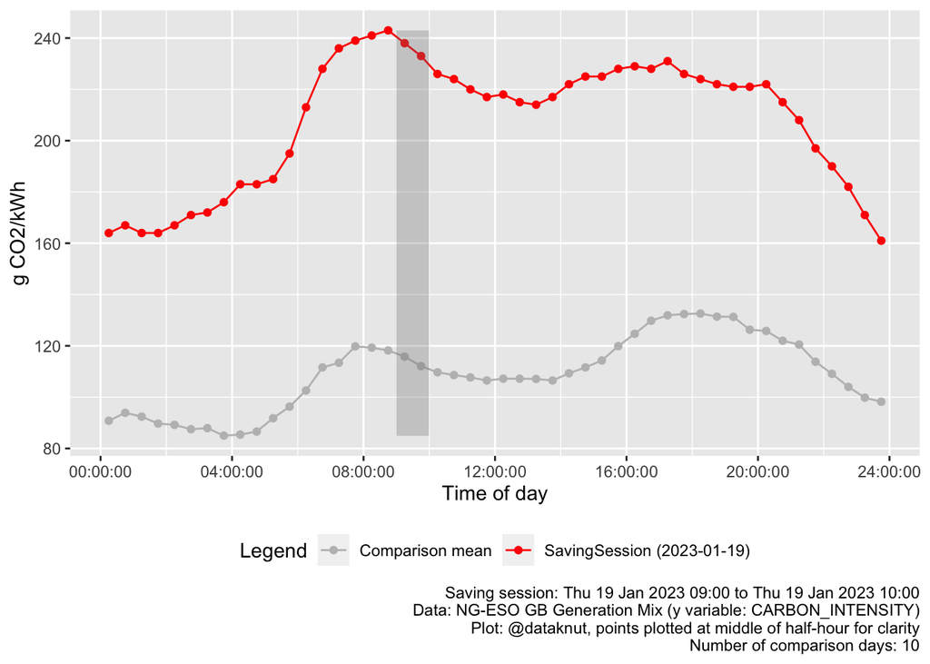

Figure 6: Comparison of carbon intensity

## 5.7 Session 7 (NG-ESO ‘live’: Mon 23 Jan 2023 17:00)

This was a more [generalised call](https://www.bbc.co.uk/news/business-64367504) for *DFS*:

- 2023-01-23 17:00:00 to
- 2023-01-23 18:00:00

The same caveats about the comparisons apply here…

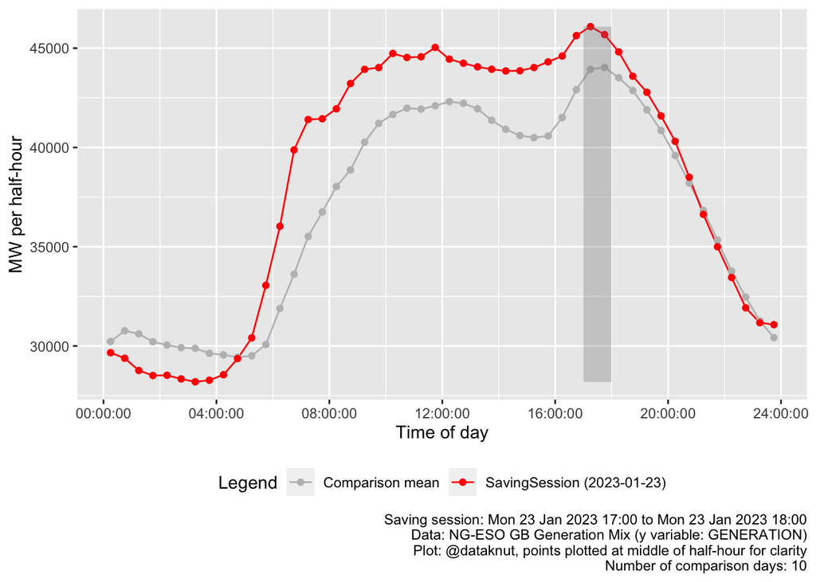

MW comparisons

| hms | Comparison mean | Saving session | MW_diff | pc_diff |
| --- | --- | --- | --- | --- |
| 17:00:00 | 43,930.7 | 46,086.0 | 2,155.3 | 4.9 |
| 17:30:00 | 44,034.9 | 45,684.0 | 1,649.1 | 3.7 |

And just to keep in mind the carbon context:

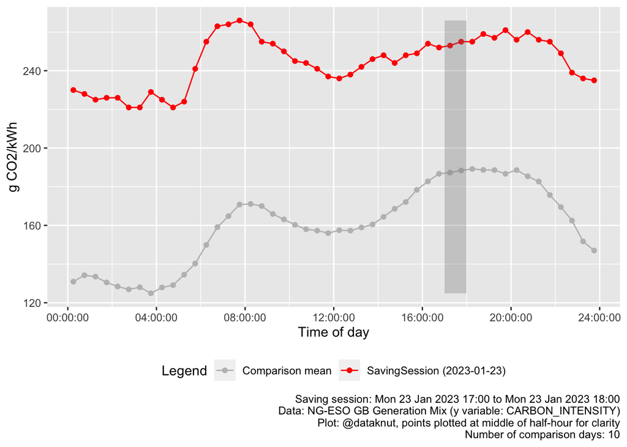

Figure 7: Comparison of carbon intensity

## 5.8 Session 8 (NG-ESO ‘live’: Tue 24 Jan 2023 16:30)

This was another [generalised call](https://www.bbc.co.uk/news/business-64372264) for *DFS*:

- 2023-01-24 16:30:00 to
- 2023-01-24 18:00:00

The same caveats about the comparisons apply here…

Also this ecent followed very soon after the last one so this will affect the comparison ‘baseline’ (previous n days).

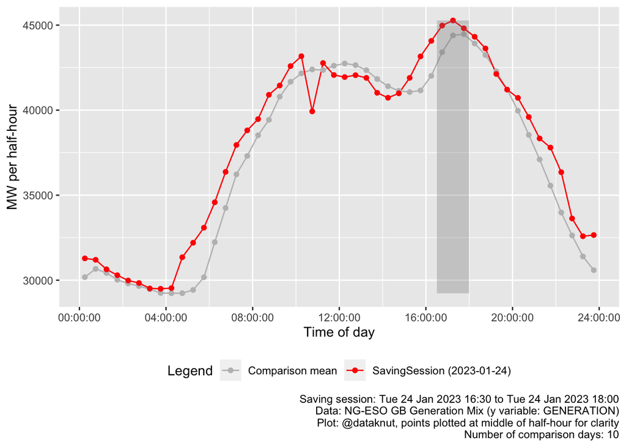

MW comparisons

| hms | Comparison mean | Saving session | MW_diff | pc_diff |
| --- | --- | --- | --- | --- |
| 16:30:00 | 43,409.2 | 44,975.0 | 1,565.8 | 3.6 |
| 17:00:00 | 44,395.9 | 45,275.0 | 879.1 | 2.0 |
| 17:30:00 | 44,466.2 | 44,814.0 | 347.8 | 0.8 |

And just to keep in mind the carbon context:

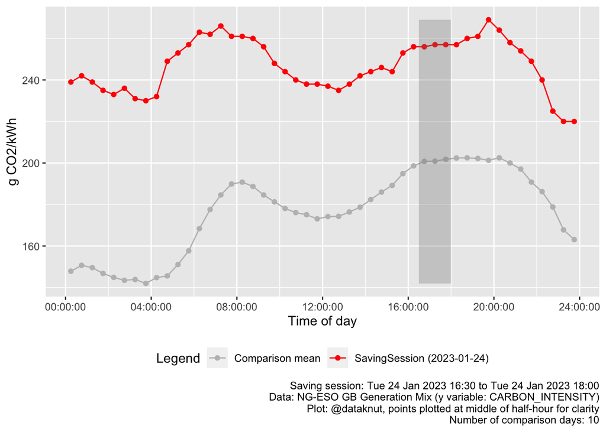

Figure 8: Comparison of carbon intensity

# 6 Future work

- more trial days
- use 5 days before/after as comparators? Confounded by events close together…